# code

## Steel Plate Defect Prediction

In this notebook we are dealing with the problem of Steel Plate Defect Prediction which is a multi classification model. The dataset consists of steel plates' faults classified into seven different types, which are all superficial damages: Pastry, Z_Scratch, K_Scatch, Stains, Dirtiness, Bumps, and Other_Faults. The last 7 columns are one hot encoded target classes. It contains 27 independent variables such as X_Minimum, Y_Minimum, Pixels_Areas, X_Perimeter, Y_Perimeter, Sum_of_Luminosity, and more. Let's dive in ...

```python
import pandas as pd
import numpy as np
import seaborn as sns
import matplotlib.pyplot as plt
import os
import csv
```

```python
for dirname, _, filenames in os.walk('~/Documents/2024_projects/project 3 : Steel Plate Defect Prediction'):
    for filename in filenames:
        print(os.path.join(dirname, filename))
```

### 1. Data loading and first exploration

To begin with we import data from csv files. We have four important csv files train and original files are use for training part. Obviously we have a test file for test the model and finally we have a sample submission four preparing data in a special format.

```python
train = pd.read_csv('train.csv')
test = pd.read_csv('test.csv')
sample_submission = pd.read_csv('sample_submission.csv')
original = pd.read_csv('original.csv')
```

After importing data we have to concatenate train and original data to increase the number of samples.

```python
train = pd.concat([train, original])
```

Let's have a look on train set

```python
train.head().T
```

|  | 0 | 1 | 2 | 3 | 4 |
| --- | --- | --- | --- | --- | --- |
| id | 0.0000 | 1.0000 | 2.000000e+00 | 3.000000e+00 | 4.0000 |
| X_Minimum | 584.0000 | 808.0000 | 3.900000e+01 | 7.810000e+02 | 1540.0000 |
| X_Maximum | 590.0000 | 816.0000 | 1.920000e+02 | 7.890000e+02 | 1560.0000 |
| Y_Minimum | 909972.0000 | 728350.0000 | 2.212076e+06 | 3.353146e+06 | 618457.0000 |
| Y_Maximum | 909977.0000 | 728372.0000 | 2.212144e+06 | 3.353173e+06 | 618502.0000 |
| Pixels_Areas | 16.0000 | 433.0000 | 1.138800e+04 | 2.100000e+02 | 521.0000 |
| X_Perimeter | 8.0000 | 20.0000 | 7.050000e+02 | 1.600000e+01 | 72.0000 |
| Y_Perimeter | 5.0000 | 54.0000 | 4.200000e+02 | 2.900000e+01 | 67.0000 |
| Sum_of_Luminosity | 2274.0000 | 44478.0000 | 1.311391e+06 | 3.202000e+03 | 48231.0000 |
| Minimum_of_Luminosity | 113.0000 | 70.0000 | 2.900000e+01 | 1.140000e+02 | 82.0000 |
| Maximum_of_Luminosity | 140.0000 | 111.0000 | 1.410000e+02 | 1.340000e+02 | 111.0000 |
| Length_of_Conveyer | 1358.0000 | 1687.0000 | 1.400000e+03 | 1.387000e+03 | 1692.0000 |
| TypeOfSteel_A300 | 0.0000 | 1.0000 | 0.000000e+00 | 0.000000e+00 | 0.0000 |
| TypeOfSteel_A400 | 1.0000 | 0.0000 | 1.000000e+00 | 1.000000e+00 | 1.0000 |
| Steel_Plate_Thickness | 50.0000 | 80.0000 | 4.000000e+01 | 4.000000e+01 | 300.0000 |
| Edges_Index | 0.7393 | 0.7772 | 5.570000e-02 | 7.202000e-01 | 0.1211 |
| Empty_Index | 0.4000 | 0.2878 | 5.282000e-01 | 3.333000e-01 | 0.5347 |
| Square_Index | 0.5000 | 0.2581 | 9.895000e-01 | 3.333000e-01 | 0.0842 |
| Outside_X_Index | 0.0059 | 0.0044 | 1.077000e-01 | 4.400000e-03 | 0.0192 |
| Edges_X_Index | 1.0000 | 0.2500 | 2.363000e-01 | 3.750000e-01 | 0.2105 |
| Edges_Y_Index | 1.0000 | 1.0000 | 3.857000e-01 | 9.310000e-01 | 0.9861 |
| Outside_Global_Index | 0.0000 | 1.0000 | 0.000000e+00 | 1.000000e+00 | 1.0000 |
| LogOfAreas | 1.2041 | 2.6365 | 4.056400e+00 | 2.322200e+00 | 2.7694 |
| Log_X_Index | 0.9031 | 0.7782 | 2.179000e+00 | 7.782000e-01 | 1.4150 |
| Log_Y_Index | 0.6990 | 1.7324 | 2.209500e+00 | 1.431400e+00 | 1.8808 |
| Orientation_Index | -0.5000 | 0.7419 | -1.050000e-02 | 6.667000e-01 | 0.9158 |
| Luminosity_Index | -0.0104 | -0.2997 | -9.440000e-02 | -4.020000e-02 | -0.2455 |
| SigmoidOfAreas | 0.1417 | 0.9491 | 1.000000e+00 | 4.025000e-01 | 0.9998 |
| Pastry | 0.0000 | 0.0000 | 0.000000e+00 | 0.000000e+00 | 0.0000 |
| Z_Scratch | 0.0000 | 0.0000 | 0.000000e+00 | 0.000000e+00 | 0.0000 |
| K_Scatch | 0.0000 | 0.0000 | 1.000000e+00 | 1.000000e+00 | 0.0000 |
| Stains | 1.0000 | 0.0000 | 0.000000e+00 | 0.000000e+00 | 0.0000 |
| Dirtiness | 0.0000 | 0.0000 | 0.000000e+00 | 0.000000e+00 | 0.0000 |
| Bumps | 0.0000 | 0.0000 | 0.000000e+00 | 0.000000e+00 | 0.0000 |
| Other_Faults | 0.0000 | 1.0000 | 0.000000e+00 | 0.000000e+00 | 1.0000 |

Here we have targets inside the train part that we have to separate these two parts for further evaluation

```python
target_classes = [ 'Pastry', 'Z_Scratch', 'K_Scatch', 'Stains','Dirtiness', 'Bumps', 'Other_Faults']
target = train[target_classes]
train = train.drop(target_classes, axis = 'columns')
```

Now the formation of train and target are clear. Let's have a look on them

```python
train.head(5).T
```

|  | 0 | 1 | 2 | 3 | 4 |
| --- | --- | --- | --- | --- | --- |
| id | 0.0000 | 1.0000 | 2.000000e+00 | 3.000000e+00 | 4.0000 |
| X_Minimum | 584.0000 | 808.0000 | 3.900000e+01 | 7.810000e+02 | 1540.0000 |
| X_Maximum | 590.0000 | 816.0000 | 1.920000e+02 | 7.890000e+02 | 1560.0000 |
| Y_Minimum | 909972.0000 | 728350.0000 | 2.212076e+06 | 3.353146e+06 | 618457.0000 |
| Y_Maximum | 909977.0000 | 728372.0000 | 2.212144e+06 | 3.353173e+06 | 618502.0000 |
| Pixels_Areas | 16.0000 | 433.0000 | 1.138800e+04 | 2.100000e+02 | 521.0000 |
| X_Perimeter | 8.0000 | 20.0000 | 7.050000e+02 | 1.600000e+01 | 72.0000 |
| Y_Perimeter | 5.0000 | 54.0000 | 4.200000e+02 | 2.900000e+01 | 67.0000 |
| Sum_of_Luminosity | 2274.0000 | 44478.0000 | 1.311391e+06 | 3.202000e+03 | 48231.0000 |
| Minimum_of_Luminosity | 113.0000 | 70.0000 | 2.900000e+01 | 1.140000e+02 | 82.0000 |
| Maximum_of_Luminosity | 140.0000 | 111.0000 | 1.410000e+02 | 1.340000e+02 | 111.0000 |
| Length_of_Conveyer | 1358.0000 | 1687.0000 | 1.400000e+03 | 1.387000e+03 | 1692.0000 |
| TypeOfSteel_A300 | 0.0000 | 1.0000 | 0.000000e+00 | 0.000000e+00 | 0.0000 |
| TypeOfSteel_A400 | 1.0000 | 0.0000 | 1.000000e+00 | 1.000000e+00 | 1.0000 |
| Steel_Plate_Thickness | 50.0000 | 80.0000 | 4.000000e+01 | 4.000000e+01 | 300.0000 |
| Edges_Index | 0.7393 | 0.7772 | 5.570000e-02 | 7.202000e-01 | 0.1211 |
| Empty_Index | 0.4000 | 0.2878 | 5.282000e-01 | 3.333000e-01 | 0.5347 |
| Square_Index | 0.5000 | 0.2581 | 9.895000e-01 | 3.333000e-01 | 0.0842 |
| Outside_X_Index | 0.0059 | 0.0044 | 1.077000e-01 | 4.400000e-03 | 0.0192 |
| Edges_X_Index | 1.0000 | 0.2500 | 2.363000e-01 | 3.750000e-01 | 0.2105 |
| Edges_Y_Index | 1.0000 | 1.0000 | 3.857000e-01 | 9.310000e-01 | 0.9861 |
| Outside_Global_Index | 0.0000 | 1.0000 | 0.000000e+00 | 1.000000e+00 | 1.0000 |
| LogOfAreas | 1.2041 | 2.6365 | 4.056400e+00 | 2.322200e+00 | 2.7694 |
| Log_X_Index | 0.9031 | 0.7782 | 2.179000e+00 | 7.782000e-01 | 1.4150 |
| Log_Y_Index | 0.6990 | 1.7324 | 2.209500e+00 | 1.431400e+00 | 1.8808 |
| Orientation_Index | -0.5000 | 0.7419 | -1.050000e-02 | 6.667000e-01 | 0.9158 |
| Luminosity_Index | -0.0104 | -0.2997 | -9.440000e-02 | -4.020000e-02 | -0.2455 |
| SigmoidOfAreas | 0.1417 | 0.9491 | 1.000000e+00 | 4.025000e-01 | 0.9998 |

```python
target.head(5).T
```

|  | 0 | 1 | 2 | 3 | 4 |
| --- | --- | --- | --- | --- | --- |
| Pastry | 0 | 0 | 0 | 0 | 0 |
| Z_Scratch | 0 | 0 | 0 | 0 | 0 |
| K_Scatch | 0 | 0 | 1 | 1 | 0 |
| Stains | 1 | 0 | 0 | 0 | 0 |
| Dirtiness | 0 | 0 | 0 | 0 | 0 |
| Bumps | 0 | 0 | 0 | 0 | 0 |
| Other_Faults | 0 | 1 | 0 | 0 | 1 |

### 2. Feature Engineering

At this point we try to do some smart feature engineering.

Coordinate Range Features: By calculating the range of coordinates (both in the x and y directions), we capture information about the spatial extent of each fault. This could be relevant because faults with larger spatial extents might indicate more severe defects or anomalies in the steel plate

```python
def calculate_coordinate_range_features(data):
    data['X_Range'] = (data['X_Maximum'] - data['X_Minimum'])
    data['Y_Range'] =( data['Y_Maximum'] - data['Y_Minimum'])
    return data

train = calculate_coordinate_range_features(train)
test = calculate_coordinate_range_features(test)
```

```python
def calculate_size_ratio_features(data):
    data['Area_Perimeter_Ratio'] = data['Pixels_Areas'] / (data['X_Perimeter'] + data['Y_Perimeter'])
    return data

train = calculate_size_ratio_features(train)
test = calculate_size_ratio_features(test)
```

Luminosity Range Feature: The range of luminosity values within a fault area can indicate variations in brightness or darkness, which might be associated with different types or severities of defects. For example, larger luminosity ranges could suggest areas with contrasting levels of brightness, potentially highlighting regions with significant defects.

```python
def calculate_luminosity_range_feature(data):
    data['Luminosity_Range'] = (data['Maximum_of_Luminosity'] - data['Minimum_of_Luminosity'])
    return data

train = calculate_luminosity_range_feature(train)
test = calculate_luminosity_range_feature(test)
```

Besides, we operate the transformation on train and test set.

```python
from sklearn.preprocessing import MinMaxScaler

train = train.astype(np.float64)
test = test.astype(np.float64)

scalar = MinMaxScaler()
scalar.fit(train)

train[:] = scalar.transform(train)
test[:] = scalar.transform(test)
```

Here we drop id column from data

```python
train = train.drop(['id'], axis = 1)
test = test.drop(['id'], axis = 1)
```

### 3. Exploratory data analysis (EDA)

Let's proceed to in deep explore and prepare the datasets. before starting, it is necessary to provide more information about features. The dataset "Steel Plates Faults" contains 27 features that describe each fault in detail. Here is an explanation of some of the features based on the information gathered from the search results:

1. Location Features:
- X_Minimum: The minimum x-coordinate of the fault.
- X_Maximum: The maximum x-coordinate of the fault.
- Y_Minimum: The minimum y-coordinate of the fault.
- Y_Maximum: The maximum y-coordinate of the fault.
2. Size Features:
- Pixels_Areas: Area of the fault in pixels.
- X_Perimeter: Perimeter along the x-axis of the fault.
- Y_Perimeter: Perimeter along the y-axis of the fault.
3. Luminosity Features:
- Sum_of_Luminosity: Sum of luminosity values in the fault area.
- Minimum_of_Luminosity: Minimum luminosity value in the fault area.
- Maximum_of_Luminosity: Maximum luminosity value in the fault area.
4. Material Features:
- TypeOfSteel_A300: Type of steel (A300).
- TypeOfSteel_A400: Type of steel (A400).
- Steel_Plate_Thickness: Thickness of the steel plate.
5. Index Features:
- Edges_Index
- Empty_Index
- Square_Index
- Outside_X_Index
- Edges_X_Index
- Edges_Y_Index
- Outside_Global_Index'
6. Logarithmic Features:
- LogOfAreas: Logarithm of the area of the fault
- Log_X_Index: Logarithmic indices related to X coordinate.
- log_Y_index: Logarithmic indices related to Y coordinate.
7. Statistical Features:
- Orientation_Index: Index describing orientation.
- Luminosity_Index: Index related to luminosity.
- SigmoidOfAreas: Sigmoid function applied to areas.

These features provide detailed information about each steel plate fault, including its location, size, material characteristics, geometric properties, and statistical attributes.

```python
train.info()
```

```
<class 'pandas.core.frame.DataFrame'>
Index: 21160 entries, 0 to 1940
Data columns (total 31 columns):
 #   Column                 Non-Null Count  Dtype
---  ------                 --------------  -----
 0   X_Minimum              21160 non-null  float64
 1   X_Maximum              21160 non-null  float64
 2   Y_Minimum              21160 non-null  float64
 3   Y_Maximum              21160 non-null  float64
 4   Pixels_Areas           21160 non-null  float64
 5   X_Perimeter            21160 non-null  float64
 6   Y_Perimeter            21160 non-null  float64
 7   Sum_of_Luminosity      21160 non-null  float64
 8   Minimum_of_Luminosity  21160 non-null  float64
 9   Maximum_of_Luminosity  21160 non-null  float64
```

[output cut: 23 more lines]

thats great! Not only there is no null parameter inside the data, but also are all the data numeric.

Let's have a look on variabels:

```python
train.nunique()
```

```
X_Minimum                 1218
X_Maximum                 1272
Y_Minimum                 3463
Y_Maximum                 3450
Pixels_Areas              1160
X_Perimeter                471
Y_Perimeter                338
Sum_of_Luminosity         2619
Minimum_of_Luminosity      165
Maximum_of_Luminosity      104
Length_of_Conveyer         100
TypeOfSteel_A300             2
TypeOfSteel_A400             2
Steel_Plate_Thickness       27
Edges_Index               1876
Empty_Index               1773
Square_Index              1137
Outside_X_Index            531
Edges_X_Index             1116
Edges_Y_Index              912
Outside_Global_Index         4
LogOfAreas                1083
Log_X_Index                210
Log_Y_Index                245
Orientation_Index         1634
Luminosity_Index          2069
SigmoidOfAreas             475
X_Range                    327
Y_Range                    917
Area_Perimeter_Ratio     10035
Luminosity_Range           166
dtype: int64
```

Here we have an interesting point. TypeOfSteel_A300 and TypeOfSteel_A400 have binary variables. Also Outside_Global_Index is interesting. In fact Outside_Global_Index is indeed a bizarre feature since it seems a binary but it has some intermediate values that we leave it alone for the moment.

```python
train['TypeOfSteel_A300'].value_counts()
```

```
TypeOfSteel_A300
0.0    12644
1.0     8516
Name: count, dtype: int64
```

```python
train['TypeOfSteel_A400'].value_counts()
```

```
TypeOfSteel_A400
1.0    12625
0.0     8535
Name: count, dtype: int64
```

```python
train['Outside_Global_Index'].value_counts()
```

```
Outside_Global_Index
1.0    12094
0.0     8268
0.5      797
0.7        1
Name: count, dtype: int64
```

### 4. Target Analysis and engineering

Let's have a look on target:

```python
target.sum(axis = 1).value_counts()
```

```
1    20321
0      818
2       21
Name: count, dtype: int64
```

That's interesting because there are some cases that they don't have any faults and on the other side there are some cases that have 2 faults which we have to consider them. Andiamo and see what exactly they are

```python
target[target.sum(axis=1)==2].head()
```

|  | Pastry | Z_Scratch | K_Scatch | Stains | Dirtiness | Bumps | Other_Faults |
| --- | --- | --- | --- | --- | --- | --- | --- |
| 634 | 0 | 0 | 1 | 0 | 0 | 0 | 1 |
| 752 | 0 | 0 | 1 | 0 | 0 | 0 | 1 |
| 3572 | 0 | 0 | 1 | 0 | 0 | 1 | 0 |
| 4416 | 0 | 0 | 1 | 0 | 0 | 0 | 1 |
| 4530 | 0 | 0 | 1 | 0 | 0 | 0 | 1 |

```python
target[target.sum(axis=1)==0].head()
```

|  | Pastry | Z_Scratch | K_Scatch | Stains | Dirtiness | Bumps | Other_Faults |
| --- | --- | --- | --- | --- | --- | --- | --- |
| 8 | 0 | 0 | 0 | 0 | 0 | 0 | 0 |
| 12 | 0 | 0 | 0 | 0 | 0 | 0 | 0 |
| 50 | 0 | 0 | 0 | 0 | 0 | 0 | 0 |
| 73 | 0 | 0 | 0 | 0 | 0 | 0 | 0 |
| 93 | 0 | 0 | 0 | 0 | 0 | 0 | 0 |

Super nice!

Given the situation, it is better to remove these 21 cases because it makes problem in upcoming parts.

```python
case_2 = list(target[target.sum(axis=1)==2].T)
```

```python
target = target.drop(case_2, axis=0 )
train = train.drop(case_2, axis=0 )
```

```python
target.sum(axis = 1).value_counts()
```

```
1    20319
0      818
Name: count, dtype: int64
```

Here we removed those rows that had 2 faults. As well as the 2 fault cases we can remove those parts of data that they don't have fault

```python
case_0 = list(target[target.sum(axis=1)==0].T)
```

```python
target = target.drop(case_0, axis=0)
train = train.drop(case_0, axis=0)
```

```python
target.sum(axis = 1).value_counts()
```

```
1    20229
Name: count, dtype: int64
```

let's have a look on barchart

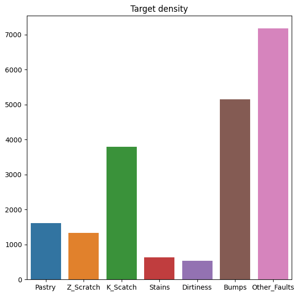

```python
tr = pd.DataFrame(target.sum(axis= 0)).T
plt.figure(figsize =(7,7))
sns.barplot( data=tr)
plt.title('Target density');
plt.show()
```

Now instead of seven column of target we tend to make a column of target. lets make it

```python
target = np.where(target["Pastry"]==1, "Pastry",
                           (np.where(target["Z_Scratch"]==1, "Z_Scratch",
                                     (np.where(target["K_Scatch"]==1, "K_Scatch",
                                               (np.where(target["Stains"]==1, "Stains",
                                                         (np.where(target["Dirtiness"]==1, "Dirtiness",
                                                                   (np.where(target["Bumps"]==1, "Bumps","Other_Faults")))))))))))
```

```python
target
```

```
array(['Stains', 'Other_Faults', 'K_Scatch', ..., 'Other_Faults',
       'Other_Faults', 'Other_Faults'], dtype='<U12')
```

Now we would like to change the target to numeric formation

```python
from sklearn.preprocessing import *
label_encoder = LabelEncoder()
target = label_encoder.fit_transform(target)
```

```python
target
```

```
array([5, 3, 2, ..., 3, 3, 3])
```

### 6. Modelling

Here for having a nice model for anticipating the targets we do cross validation and optimization inside the model. Lets describe the process and first we start with cross validation. Cross-validation is a statistical technique used in machine learning and model evaluation to assess how well a trained model will generalize to new, unseen data. It involves partitioning the dataset into multiple subsets, known as folds. The model is trained on a portion of the data (training set) and then evaluated on the remaining portion (validation set or test set). This process is repeated multiple times, with each fold serving as the validation set exactly once, while the remaining folds are used for training. The most common type of cross-validation is k-fold cross-validation, where the dataset is divided into k equal-sized folds. The model is trained k times, each time using a different fold as the validation set and the remaining folds as the training set. The result of cross validation is index of the data that we can consider for both target and train parts for separation.

```python
from sklearn.model_selection import StratifiedKFold

cv = StratifiedKFold(5, shuffle=True, random_state=0)
cv_splits = cv.split(train, y=target)
```

Here we have five fold consist of index of the data in train and target part which by using .iloc or .loc we can find their location among train and test part.

```python
list(cv_splits)
```

```
[(array([    0,     1,     2, ..., 20225, 20227, 20228]),
  array([    4,    18,    40, ..., 20219, 20220, 20226])),
 (array([    0,     1,     4, ..., 20225, 20226, 20228]),
  array([    2,     3,     7, ..., 20212, 20215, 20227])),
 (array([    0,     1,     2, ..., 20226, 20227, 20228]),
  array([    5,     8,    17, ..., 20214, 20218, 20225])),
 (array([    0,     1,     2, ..., 20226, 20227, 20228]),
  array([   10,    12,    14, ..., 20213, 20221, 20222])),
 (array([    2,     3,     4, ..., 20225, 20226, 20227]),
  array([    0,     1,     6, ..., 20223, 20224, 20228]))]
```

Moreover, we are using optuna library for optimizing the hyper parameters. in this part we are using the xgboost for classification and let see the result

```python
from xgboost import XGBClassifier
from sklearn.metrics import *
import optuna

def objective(trial):
    params = {
                'grow_policy': trial.suggest_categorical('grow_policy', ["depthwise", "lossguide"]),
                'n_estimators': trial.suggest_int('n_estimators', 100, 1000),
                'learning_rate': trial.suggest_float('learning_rate', 0.01, 1.0, log=True),
                'gamma' : trial.suggest_float('gamma', 1e-9, 0.5),
                'subsample': trial.suggest_float('subsample', 0.3, 1.0),
                'colsample_bytree': trial.suggest_float('colsample_bytree', 0.3, 1.0),
                'max_depth': trial.suggest_int('max_depth', 0, 12),
                'min_child_weight': trial.suggest_int('min_child_weight', 1, 7),
                'reg_lambda': trial.suggest_float('reg_lambda', 1e-9, 100.0, log=True),
                'reg_alpha': trial.suggest_float('reg_alpha', 1e-9, 100.0, log=True),
    }


    cv = StratifiedKFold(5, shuffle=True, random_state=0)
    cv_splits = cv.split(train, y=target)
    cv_scores = list()

    for train_idx, val_idx in cv_splits:

        xgb = XGBClassifier(**params)

        X_train_fold, X_val_fold = train.iloc[train_idx], train.iloc[val_idx]
        y_train_fold, y_val_fold = target[train_idx], target[val_idx]

        xgb.fit(X_train_fold, y_train_fold)

        y_val_prob = xgb.predict(X_val_fold)
        cv_scores.append(accuracy_score(y_val_fold, y_val_prob))

    cv_evaluation = np.mean(cv_scores)

    return cv_evaluation

study = optuna.create_study()
study.optimize(objective, n_trials=10)
best_cls_params = study.best_params
best_value = study.best_value
best_cls_params['objective'] = 'multi:softmax'
best_cls_params['tree_method'] = "hist"
best_cls_params["device"] = "cuda"
best_cls_params["verbosity"] = 0
```

Now we can make the model by using parameters that are optimized by optuna and we can use them in xgboost classifier

```python
from xgboost import XGBClassifier

xgb = XGBClassifier(**best_cls_params)
xgb.fit(train, target)
y_pred = xgb.predict(test)
```

### 7. Submission file

```python
y_p = label_encoder.inverse_transform(y_pred)
```

```python
y_p
```

```
array(['Other_Faults', 'Dirtiness', 'Other_Faults', ..., 'K_Scatch',
       'Other_Faults', 'K_Scatch'], dtype='<U12')
```

```python
d = y_p.shape[0]
```

```python
d = y_p.shape[0]
data = pd.DataFrame(np.zeros((d,7),dtype=int), columns=["Pastry", "Z_Scratch", "K_Scatch", "Stains", "Dirtiness","Bumps","Other_Faults"])
for i in range(d):
    if y_p[i]=="Pastry":
        data['Pastry'][i]=1
    elif y_p[i]=="Z_Scratch":
        data['Z_Scratch'][i]=1
    elif y_p[i]=="K_Scatch":
        data['K_Scatch'][i]=1
    elif y_p[i]=="Stains":
        data['Stains'][i]=1
    elif y_p[i]=="Dirtiness":
        data['Dirtiness'][i]=1
    elif y_p[i]=="Bumps":
        data['Bumps'][i]=1
    elif y_p[i]=="Other_Faults":
        data['Other_Faults'][i]=1
```

```python
data.to_csv
```

[output not shown]

12814 rows × 7 columns

```python
data['id'] = sample_submission['id']
```

```python
final = data[['id', "Pastry", "Z_Scratch", "K_Scatch", "Stains", "Dirtiness","Bumps","Other_Faults"]]
```

```python
final.to_csv("submission.csv",index=False)
final.head(10)
```

|  | id | Pastry | Z_Scratch | K_Scatch | Stains | Dirtiness | Bumps | Other_Faults |
| --- | --- | --- | --- | --- | --- | --- | --- | --- |
| 0 | 19219 | 0 | 0 | 0 | 0 | 0 | 0 | 1 |
| 1 | 19220 | 0 | 0 | 0 | 0 | 1 | 0 | 0 |
| 2 | 19221 | 0 | 0 | 0 | 0 | 0 | 0 | 1 |
| 3 | 19222 | 0 | 0 | 0 | 0 | 0 | 1 | 0 |
| 4 | 19223 | 0 | 0 | 0 | 0 | 0 | 1 | 0 |
| 5 | 19224 | 0 | 0 | 0 | 0 | 0 | 0 | 1 |
| 6 | 19225 | 0 | 0 | 0 | 0 | 0 | 0 | 1 |
| 7 | 19226 | 0 | 0 | 0 | 0 | 0 | 0 | 1 |
| 8 | 19227 | 0 | 1 | 0 | 0 | 0 | 0 | 0 |
| 9 | 19228 | 1 | 0 | 0 | 0 | 0 | 0 | 0 |